# Data Challenge 4

Yifan Lu

https://github.com/cclyfblink/Data_Challenge_5_Yifan_Lu

```r
## load in the required libraries
library(tidyverse)

## disable scientific notation
options(scipen = 999)
```

## Problem 1

Use the gene expression data in Ch10Ex11.csv that is provided for you on Canvas. This is gene expression data that consists of 40 tissue samples with measurements on 1,000 genes. The first 20 samples are from healthy patients, while the second 20 are from a diseased group.

Load the data – note that there is no header so you will need to read this in without one. Note that rows in this dataset represent genes and columns subjects. You will need to transpose the data using the function t() before you cluster (as we would like to cluster subjects). Scale the data. Using the code from the lecture notes and the kmeans function in R, produce the associated elbow plot (i.e., a plot of within-cluster sum of squares vs. cluster size). You can use 1 through 15 for your k values. Given your plot, what is the appropriate number of clusters for the data? Why? Cluster the scaled data using the kmeans function in R. Try this with the number of clusters you concluded in Step 3 and 50 iterations. Summarize the results in a contingency table. A contingency table is a tabular representation of categorical data that typically shows the frequency of the combinations of the two variables (i.e., an m by n table). Here we would like to show a table of our clustering versus the true disease status of the subjects. Create a variable of the disease status for the 40 tissue samples. Use the clustering that you obtained in the previous step. Create a table of the two variables using table(). Comment on what you observe. Don’t forget to set a seed number before running any function that introduces randomness!

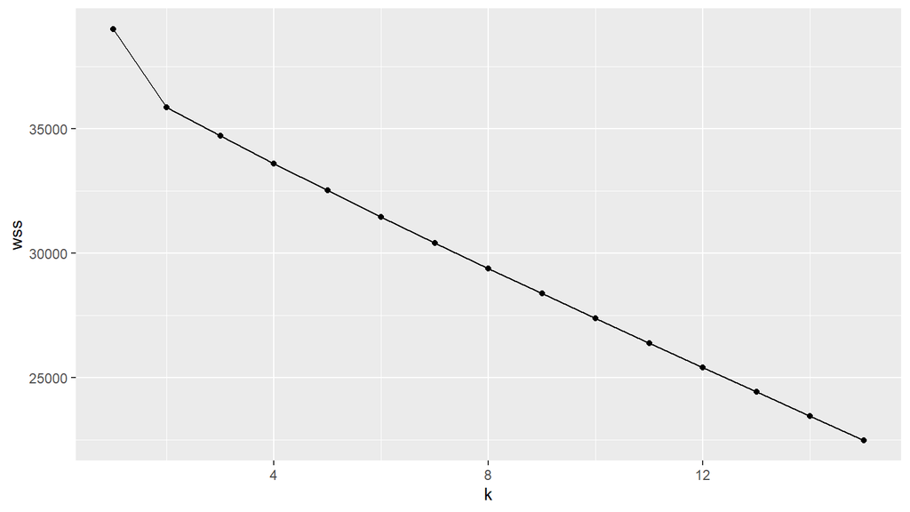

```r
# load in the data
data <- read.csv("Ch10Ex11.csv", header = FALSE) |> t()
scaled_data <- scale(data)

# code in the lecture notes
set.seed(123)
wss <- function(k, data) {
  kmeans(data, k, nstart = 50)$tot.withinss
}
k_values <- 1:15
wss_values <- map_dbl(k_values, wss, data = scaled_data)

wss_values <- tibble(wss = wss_values,
                     k = k_values)
ggplot(wss_values, aes(x = k, y = wss)) + geom_point() + geom_line()
```

Given the elbow plot, the appropriate number of clusters for the data is 2. Because the elbow plot shows that the within-cluster sum of squares decreases dramatically from 1 to 2, and then decreases with constant slope from 2 to 15.

```r
# cluster the data using kmeans()
k_means_results <- kmeans(scaled_data, centers = 2, nstart = 50)
k_means_results$cluster
```

```
##  V1  V2  V3  V4  V5  V6  V7  V8  V9 V10 V11 V12 V13 V14 V15 V16 V17 V18 V19 V20
##   1   1   1   1   1   1   1   1   1   1   1   1   1   1   1   1   1   1   1   1
## V21 V22 V23 V24 V25 V26 V27 V28 V29 V30 V31 V32 V33 V34 V35 V36 V37 V38 V39 V40
##   2   2   2   2   2   2   2   2   2   2   2   2   2   2   2   2   2   2   2   2
```

```r
disease <- c(rep("Healthy", 20), rep("Diseased", 20))

# create a contingency table of the clustering versus the disease status
table(k_means_results$cluster, disease)
```

```
##    disease
##     Diseased Healthy
##   1        0      20
##   2       20       0
```

If we assume that the clustering results are the true disease status, then the contingency table shows that all the healthy patients are clustered into one group, and all the diseased patients are clustered into another group.

## Problem 2

Perform hierarchical clustering on the same scaled data set.

Calculate the Euclidean distance between the observations. Perform hierarchical clustering on the data using the below linkages, and plot the dendograms for each linkage: complete linkage single linkage average linkage Determine clusters for 2 groups from all three methods using cutree(). Make three contingency tables for the results. Comment on what you observe.

```r
# calculate the Euclidean distance between the observations
distances <- dist(scaled_data, method = "euclidean")
```

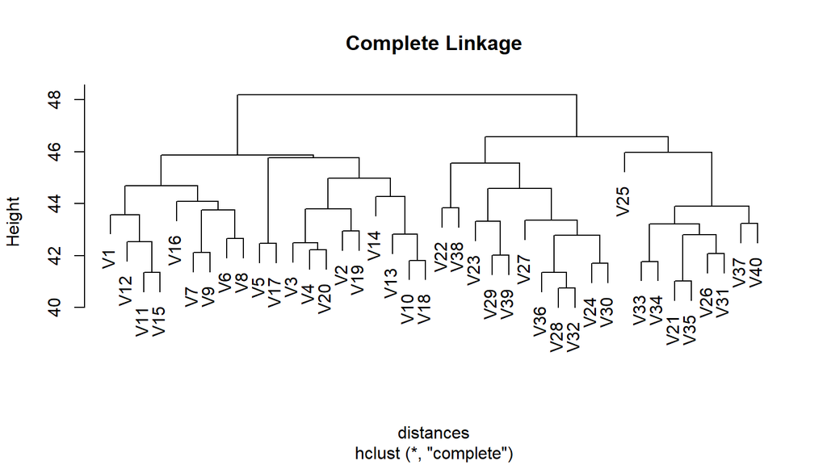

```r
# perform hierarchical clustering on the data using the below linkages
# complete linkage
hc_complete <- hclust(distances, method = "complete")
plot(hc_complete, main = "Complete Linkage")
```

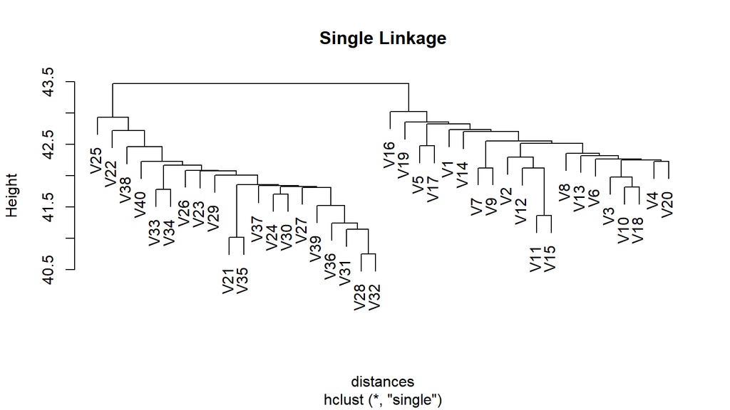

```r
# single linkage
hc_single <- hclust(distances, method = "single")
plot(hc_single, main = "Single Linkage")
```

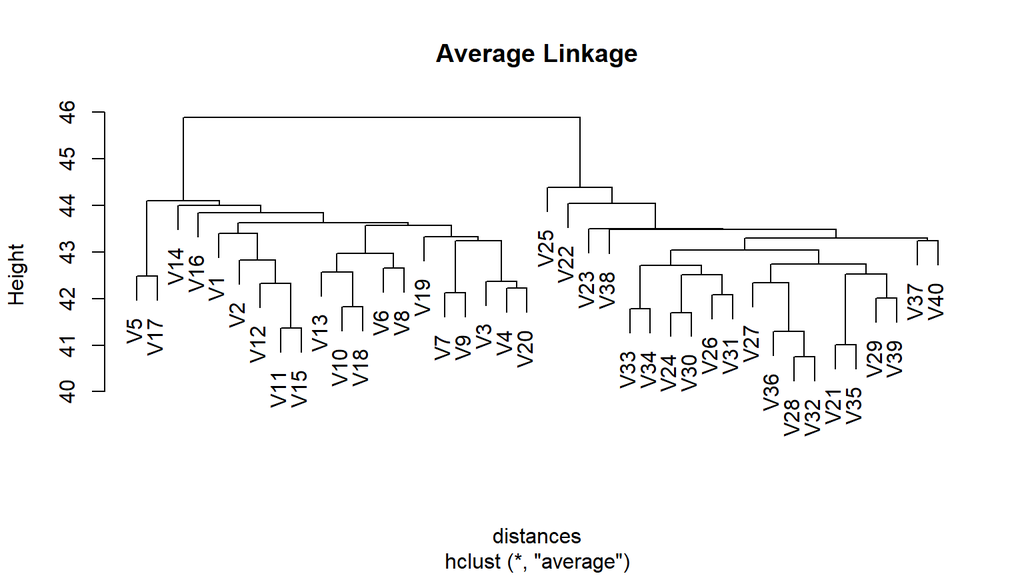

```r
# average linkage
hc_average <- hclust(distances, method = "average")
plot(hc_average, main = "Average Linkage")
```

```r
# determine clusters for 2 groups from all three methods using cutree()
# complete linkage
cutree(hc_complete, k = 2)
```

```
##  V1  V2  V3  V4  V5  V6  V7  V8  V9 V10 V11 V12 V13 V14 V15 V16 V17 V18 V19 V20
##   1   1   1   1   1   1   1   1   1   1   1   1   1   1   1   1   1   1   1   1
## V21 V22 V23 V24 V25 V26 V27 V28 V29 V30 V31 V32 V33 V34 V35 V36 V37 V38 V39 V40
##   2   2   2   2   2   2   2   2   2   2   2   2   2   2   2   2   2   2   2   2
```

```r
# single linkage
cutree(hc_single, k = 2)
```

```
##  V1  V2  V3  V4  V5  V6  V7  V8  V9 V10 V11 V12 V13 V14 V15 V16 V17 V18 V19 V20
##   1   1   1   1   1   1   1   1   1   1   1   1   1   1   1   1   1   1   1   1
## V21 V22 V23 V24 V25 V26 V27 V28 V29 V30 V31 V32 V33 V34 V35 V36 V37 V38 V39 V40
##   2   2   2   2   2   2   2   2   2   2   2   2   2   2   2   2   2   2   2   2
```

```r
# average linkage
cutree(hc_average, k = 2)
```

```
##  V1  V2  V3  V4  V5  V6  V7  V8  V9 V10 V11 V12 V13 V14 V15 V16 V17 V18 V19 V20
##   1   1   1   1   1   1   1   1   1   1   1   1   1   1   1   1   1   1   1   1
## V21 V22 V23 V24 V25 V26 V27 V28 V29 V30 V31 V32 V33 V34 V35 V36 V37 V38 V39 V40
##   2   2   2   2   2   2   2   2   2   2   2   2   2   2   2   2   2   2   2   2
```

```r
# make three contingency tables for the results
# complete linkage
table(cutree(hc_complete, k = 2), disease)
```

```
##    disease
##     Diseased Healthy
##   1        0      20
##   2       20       0
```

```r
# single linkage
table(cutree(hc_single, k = 2), disease)
```

```
##    disease
##     Diseased Healthy
##   1        0      20
##   2       20       0
```

```r
# average linkage
table(cutree(hc_average, k = 2), disease)
```

```
##    disease
##     Diseased Healthy
##   1        0      20
##   2       20       0
```

We can see that all three linkage methods have the same contingency table. If we assume that the clustering results are the true disease status, then the contingency table shows that all the healthy patients are clustered into one group, and all the diseased patients are clustered into another group.

## Problem 3

Write a few sentences commenting on the results you obtained in Problems 1 and 2.

**Answer:** In problem 1 and 2, if our assumption on the disease status of the tissues are correct, then both k-means and hierarchical clustering methods can cluster the healthy and diseased patients into the same two groups. This might indicates that the tissue of diseased and healthy have clear gene expression differences. The elbow plot may also corroborate this, there are no significant slope change in WSS after k = 2 clusters. Besides, those 3 dendrograms also have higher height at k = 2 clusters, which also indicates that the data can be clustered into 2 groups.